# A Twitter Data Analysis of the COVID-19 Impact in One’s Life 🦠

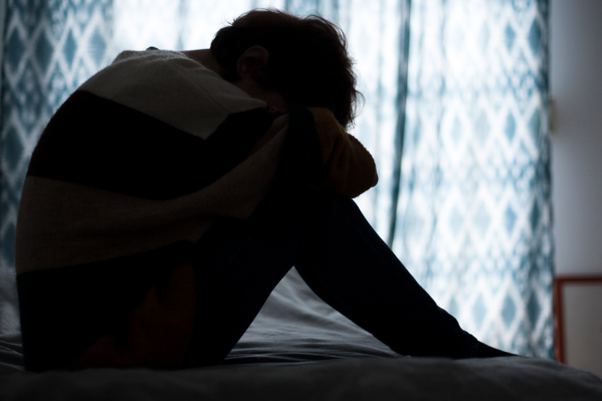

Photo: Macie J. Luczniewski - Nurphoto/Getty Images

Under the broad research question: `What are the impacts of COVID-19 in one’s life?` Our team collected Twitter data to answer research hypothesis, producing models, and have a better understanding of the factors that influence one’s reaction to the global pandemic. Our team collected more than 300 thousand tweets ranging from 2009 to November of 2020. We utilized the open source software R [1] and the Rstudio [2] in order to gather the tweets and perform the different statistical analysis. We also utilized Git [3] and GitHub [4] to organize and share our project with the community. If you wish to check the coding behind all the statistical models and other relevant topics of the project, please access the folder named “Scripts”. If you wish to have access to the graphs generated throughout our project, please access the folder named “Images”.

## The Contributors for this Project

- **Arianna Lupi** (*@ariannalupi*) - ST. Thomas University Carnival Cruise Lines School of Science
- **Enzo Novi Migliano** (*@EnzoNMigliano*) - ST. Thomas University Carnival Cruise Lines School of Science
- **Raul Ramon** (*@raulramon*) - ST. Thomas University Carnival Cruise Lines School of Science

## R Packages Utilized

In other to perform all the statistical analysis and gather the data from Twitter we utilized several packages:

| Package Name |  | Package Name |  | Package Name |  | Package Name |  |
| --- | --- | --- | --- | --- | --- | --- | --- |
| [5] | tidyverse | [6] | corrplot | [7] | caTools | [8] | caret |
| [9] | forecast | [10] | arules | [11] | arulesViz | [12] | lubridate |
| [13] | stringr | [14] | tm | [15] | quanteda | [16] | reshape2 |
| [17] | lda | [18] | syuzhet | [19] | wordcloud2 | [20] | RColorBrewer |
| [21] | party | [22] | rpart | [23] | rpart.plot | [24] | e1071 |
| [25] | rtweet | [26] | RMySQL | [27] | odbc | [28] | DBI |

# Motivations & Past Research

COVID has affected every aspect of our lives, the way we gather, work, communicate, relate, and live. Even though we are seeing some improvements and we are slowly starting to see things go back to normal this pandemic has definitely taken a toll on everyone’s physical and mental health.

### Motivation

Our motivation for this Project is to understand how people are currently feeling around COVID and what’s their state of mind during the pandemic, in specific for the front line workers, people who tested positive for COVID-19, and people’s affects towards the vaccine.

### Past Research

Despite the fact that the pandemic is fairly recent in our society, some research has been done in regards of the impact of COVID-19 in people’s lives. The pandemic has been analyzed, however, in a large spectrum, in other words, in many studies the COVID-19 overall effect in society was the main purpose. The results of such studies are great to understand the impact of COVID-19 as a whole, for example, according to Chakraborty et al.[29] people majorly tweeted positive messages regarding COVID-19, but re-tweeted the negative tweets. However, they do not offer much insight of the impact of COVID-19 in specific groups or individuals, which is the focus of the present project.

Other research:

- Global Sentiment Analysis Of COVID-19 Tweets Over Time https://arxiv.org/abs/2010.14234
- COVID-19 Public Sentiment Insights and Machine Learning for Tweets Classification https://www.mdpi.com/2078-2489/11/6/314/htm

## The Present Study

### Statistical Analysis

Among the several supervised and unsupervised statistical models the most frequent ones in the present project were:

- Decision Trees
- Association Rules
- Time Series
- Sentiment Analysis

## Research Questions

Covid-19 impacted the life of many, as several people got infected with the disease or even passed away. The scope of the consequences that pandemic brought to society is huge, therefore, the present project approached, under the theme Covid-19 impact in one’s life, three major research questions:

**How Covid-19 impacted the people who were infected and/or tested positive for the disease?**

**How Covid-19 impacted the front line workers?**

**What are the expectations of the Covid-19 vaccine?**

## ✔️ Covid-19

### ✔️ How Covid-19 impacted the people who were infected and/or tested positive for the disease?

Covid-19 has been trending topic in all information and social platforms for the past year. Human interaction has been reduced to a minimum and people have turned to social media to account for their daily activities and to fill the void social distancing has cause. “I have Covid-19.” “I got symptoms.” “I test positive.” These are words no one wishes to express to a loved one, however, they have become more and more common since the pandemic began. The objective of the search queries was to identify among Twitter users those instances in which the users informed in social media that they had Covid-19 symptoms or had positive Covid-19 diagnosis.

#### The Sentimental Analysis

Exploring some principal phrases like “I have Covid-19.” “I got symptoms.” “I test positive” We found that the phrases where mentioned with the wide range of instances like 5,429 for “I have Covid”, 1,067 for “I test Positive” and just 316 for “I got Symptoms”. In our process to understand the phrases or the words we made a histogram for the most common word uses and covid it is mentioned in the tweets text 6,495 for 6,443 tweets downloaded. The “tested word we can see just 1,2009 in second rank follow by “positive” with 1,062 times used.

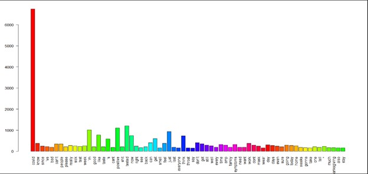

The following visualization is to see how the word ‘covid’ is use in relation to other words.

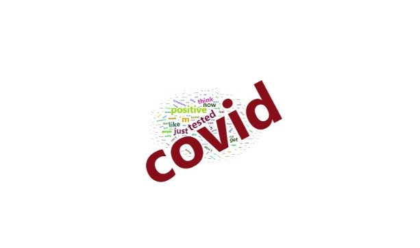

#### Cluster

For the cluster analysis I select the variables that work for the model. The cluster is important for the data analysis, is the job of grouping variables or attributes in the same group that represent the same hierarchical clustering. The Elbow method is to define clusters and the cluster inside variation. The following K-mean cluster indicate that two cluster is the distribution for this data for “followers” and “favorites”.

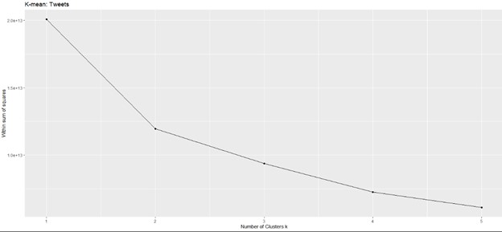

The first data show that the within cluster sum of sum squares is 59.2%. The following visualization is for the Kmeans Cluster Followers and Favorites for tweets.

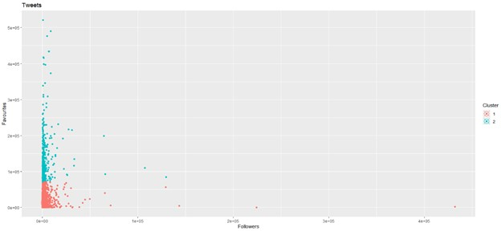

The second cluster analysis data show that the within cluster sum of sum squares is 53.2%. The following visualization is for the Kmeans Cluster Followers and Friends for tweets.

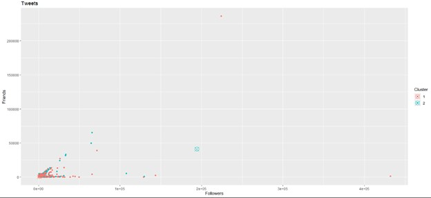

#### Cluster of test/word from the tweeter

Not enough with the tweets I decide to build a cluster test word for the text tweets and the result was that the ‘covid ‘ as a principal selection it’s connect with two other “positive , test” and “mask and wear”. We can appreciate this in the Hierarchical word/tweeter clustering using dendrogram.

#### Plot Frequent term

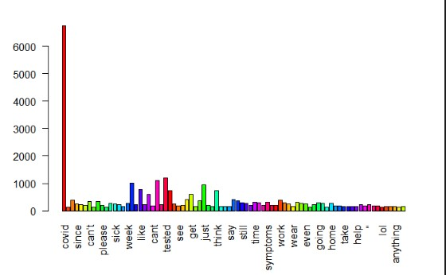

#### Hierarchical word/tweeter clustering using dendrogram

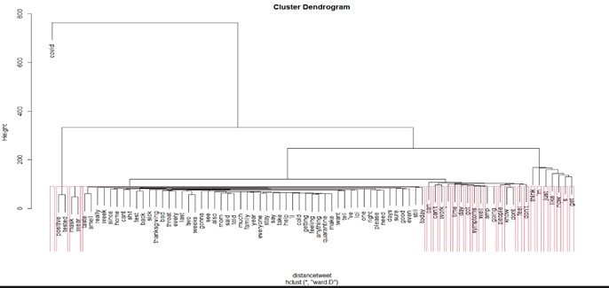

Using dendrogram cluster the algorithm indicates that the within cluster sum square by cluster is 26.4%.

#### Logistic Model

For the logistic Model we prepare the variable source from the tweets and we classify the in two groups ‘Mobile’ and ‘Web app’. The dependent variables were ‘source’ and the other variables like ‘display width’, ‘followers’, ‘friends’, ‘listed’, ‘statuses’ and ‘favorites’. The model shows that the interaction with display text width, the listed count and the status count are the only variables that represent significant differences.

glm(formula = source ~ ., family = binomial, data = train_lgtweets)

Deviance Residuals: Min 1Q Median 3Q Max  
-1.9569 -0.5288 -0.4613 -0.4195 2.7118

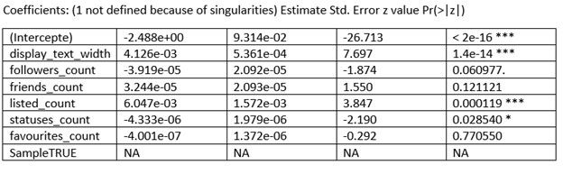

Confusion Matrix and Statistics Reference Prediction Mobile WEB_APP Mobile 1398 2 WEB_APP 192 0

```
           Accuracy : 0.8781
             95% CI : (0.8611, 0.8938)
No Information Rate : 0.9987
P-Value [Acc > NIR] : 1

              Kappa : -0.0025
```

Mcnemar’s Test P-Value : <2e-16

Sensitivity: 0.8792  
Specificity: 0.0000  
Pos Pred Value: 0.9986  
Neg Pred Value: 0.0000  
Prevalence: 0.9987  
Detection Rate: 0.8781  
Detection Prevalence: 0.8794  
Balanced Accuracy: 0.4396

```
   'Positive' Class: Mobile
```

Precision is: 0.9985714 Recall is: 0.8792453

#### Decision Tree

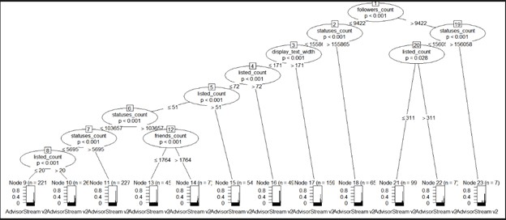

The accuracy of the model is 67.41%

## 🏥 Covid-19

### How Covid-19 impacted the front line workers?

Our Team collected a sample of 993 tweets in the month of October of 2020. The Tweets were gathered using the following expressions, contained in the following R code, as search querries: **testingFilter <- search_tweets(q = “"I am a nurse" OR "I am a doctor" OR "I am a caregiver" OR "I am a nursing home caregiver" OR "I am a nursing home worker" OR "I work at a hospital" OR "I work at a nursing home" OR "I work at the medical field" AND -filter:verified”,n = 10, include_rts = FALSE)**. The objective of the search querries was to find the Twitter users that are front line workers. Thereafter, we extracted the time lines of those users up to 400 tweets back in time. Both data sets, the initial search query and the data set with all the time lines were the base for most of the analysis about the impact of Covid in the front line workers. If you wish to see the source code for the data collection access the “Scripts” folder in the GitHub page, the initial search that resulted from the search query is listed in the folder called “Data”.

**Here are some sample tweets from the original 993 tweets extracted from the front line workers:**

> “@MileyCyrus @CashApp $lissamc1123 **I work at a nursing home** and it’s so **hard during covid**, we’ve been in **lockdown for almost 9 months**, I’m getting so **burnt out** and this would mean so much🖤 https://t.co/ZV7Q14rqfZ”

> “@IlluminatiEyes **I am a nurse who left the ICU** four years ago to get away from the stress. I am **back working in ICU due to covid**. So far we have had to create an additional 20 ICU beds, rent equipment, and pull staff from other areas. These are the **sickest patients that I have seen in almost 20 y**”"

> “**I am grateful** for Mrs Ruth Khoza and Dr Thulani Khoza of #Ulundi , South Africa for paying my registration fee to #medicalschool. **I am forever #grateful**. Today **I am a doctor** because they planted a seed, **they believed in me**. **Believe in someone**, ://t.co/EAlvQbFO5p”

> "❤❤❤❤*I am a nurse and educator**. These times have been hard for everyone. For me, I worry for those who are ill and those who are not. Will we be able to** keep ppl healthy?** Will we be able to care for them all?*I am SO proud** we have a leader who cares about people’s lives. 🙏🏼 https://t.co/J3fnVamXpB"

#### Time Series Analysis and Non-Linear Regression

In order to show how relevant Twitter is as a platform for the front line workers to express themselves, in special during the pandemic, our team developed a time series analysis for the tweets that we gathered. The first time series analysis was about the amount of tweets tweeted, starting from the oldest tweet we gathered up to the newest one. Followed by a forecast for the next 6 months.

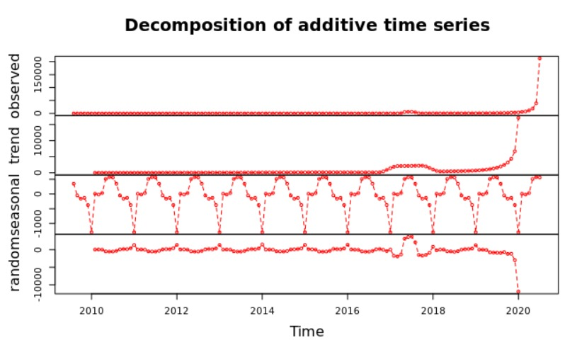

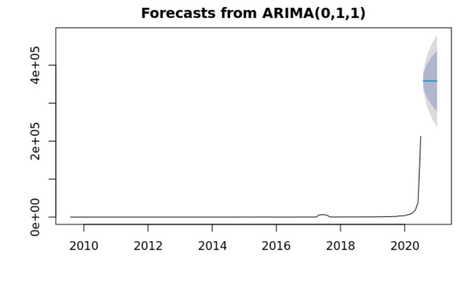

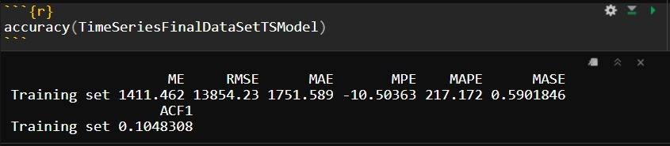

This time series analysis is even more insightful than the previous ones. The time series takes into account the number of accounts created over the time. Followed by a forecast of the next 6 months. As we can observe in the year of 2020 there was a boom of accounts created among the front line workers.

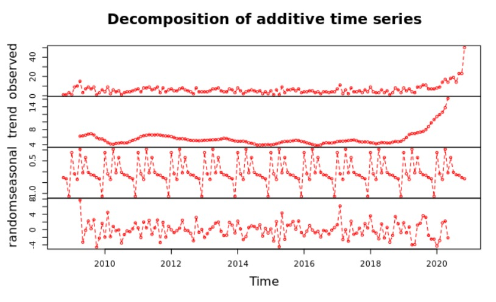

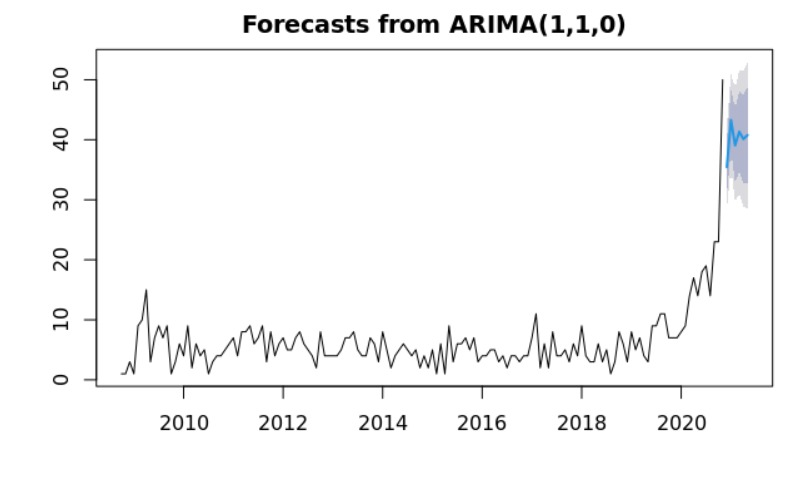

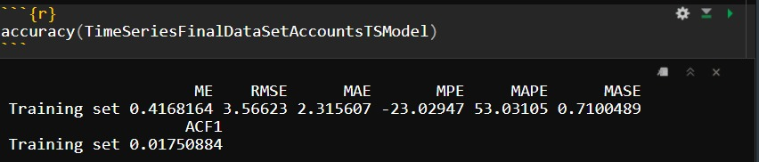

Lastly, our team performed a non linear regression to predict the cumulative number of tweets given the cumulative number of accounts. The graph demonstrate the exponential relationship between the cumulative number of accounts created and the cumulative number of tweets.

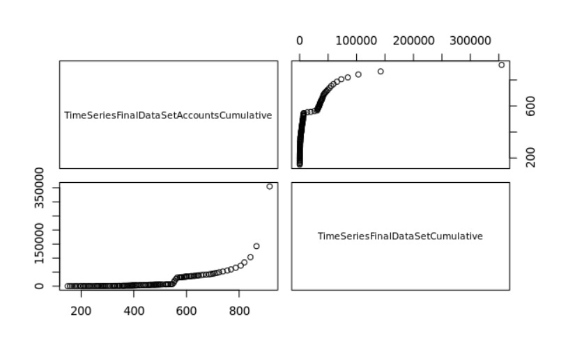

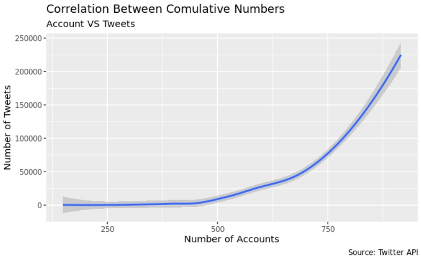

The Loess method MSE was 1684444415, the MAE 19889.79, RMSE 41041.98.

#### Sentment Analysis

##### Method

In other to interpret what the front line workers were saying in their tweets, our team utilized codes to remove punctuation, stop words of the English language(e.g., the), get the word stream (e.g., workers, working and worked were transformed in work), and to transform all the words in lowercase so the analysis could be done in the general idea rather than the specific message of the tweet. Also, after performing all the transformations in the tweets, our team utilized the NRC Word-Emotion Association Lexicon from the package syuzhet[18]. The package utilizes a crowdsource dictionary were people assigned several thousands of words to different feelings and emotions. The package utilizes those classified words as references and classify the words from the tweets to the following categories:

| Sentiment | Emotion | Emotion | Emotion | Emotion |
| --- | --- | --- | --- | --- |
| Positive | Trust | Joy | Anticipation | Surprise |
| Negative | Sadness | Disgust | Anger | fear |

##### Front Line Workers Tweets Before 2020

**500 more frequent words**

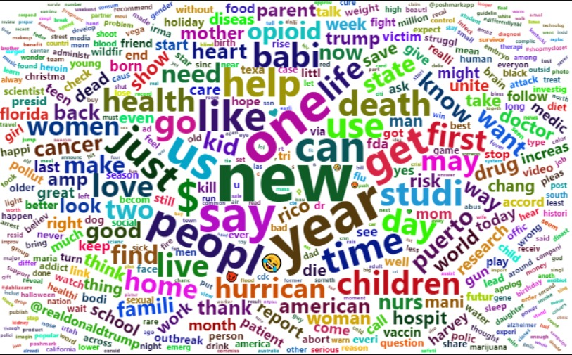

**Top 10 Words**

| Word | Frequency |
| --- | --- |
| new | 3120 |
| year | 2573 |
| one | 2455 |
| say | 2215 |
| us | 2158 |
| can | 1927 |
| poepl | 1919 |
| get | 1867 |
| like | 1853 |
| $ | 1849 |

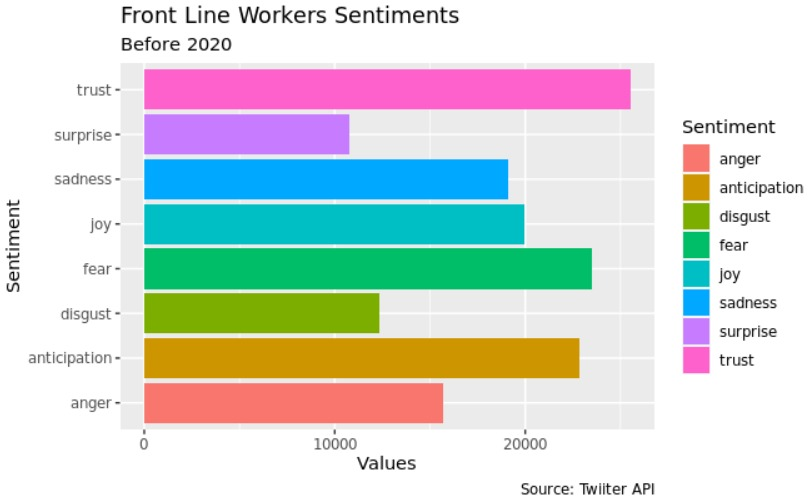

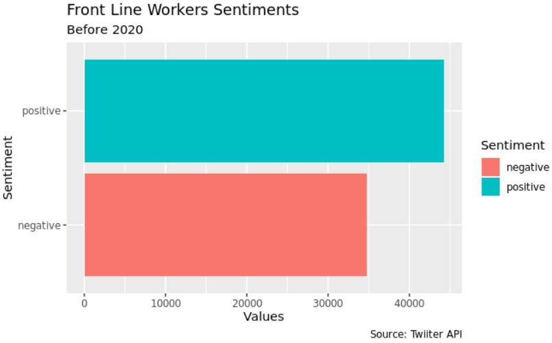

##### Front Line workers Tweets During the First Half of 2020

**500 more frequent words**

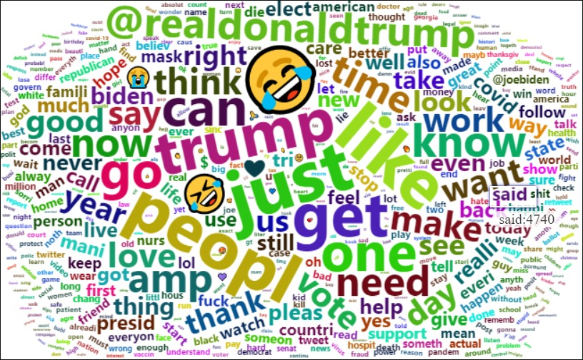

**Top 10 Words**

[output not shown]

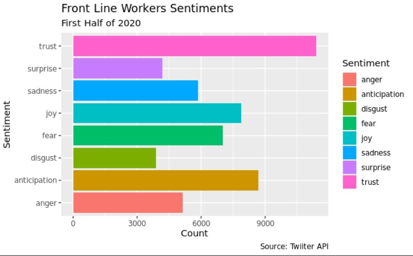

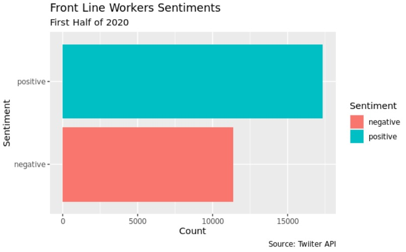

##### Front Line workers Tweets During the Second Half of 2020

**500 more frequent words**

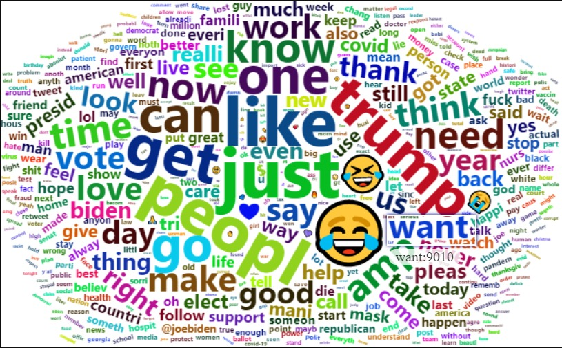

**Top 10 Words**

| Word | Frequency |
| --- | --- |
| just | 18359 |
| like | 18178 |
| peopl | 17245 |
| trump | 15794 |
| get | 15784 |
| :joy: | 15434 |
| one | 13887 |
| can | 13512 |
| go | 13067 |
| know | 11331 |

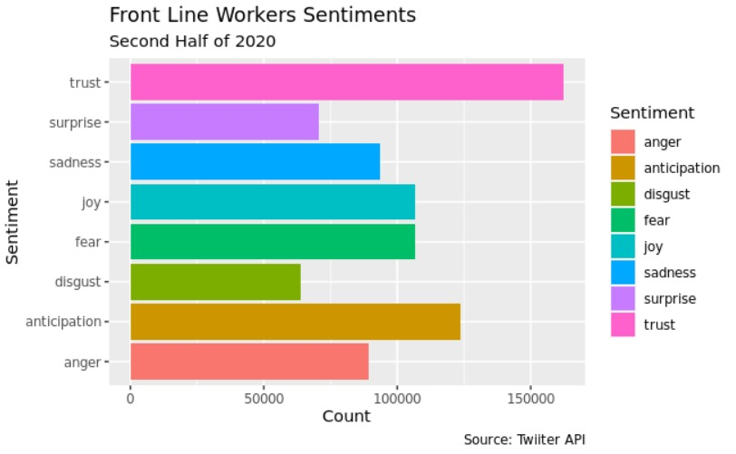

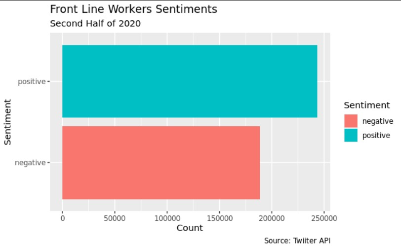

##### Results

In other to analyze if there significant changes in how the front line expressed themselves in Twitter, our team performed a serie of proportion tests.

##### Comparison between before 2020 and the first half of 2020

- The proportion of front line workers that transmitted **trust, surprise, joy and positive emotions thought the tweets in the first half of 2020 was significantly higher than before 2020 (p < 0.001)**
- The proportion of front line workers that transmitted **fear, anger, sadness, and negative thought the tweets in the first half of 2020 was significantly lower than before 2020 (p < 0.001)**

##### Comparisons within a period

##### Negative vs Positive

- The proportion of front line workers that transmitted **negative sentiments thought the tweets was significantly lower than positive sentiments in all periods(p < 0.001)**

##### Sadness vs Joy

- The proportion of front line workers that transmitted **sadness thought the tweets was significantly lower than joy sentiments in all periods(p < 0.001)**